[figure not shown]

# Using STATA’s *firthlogit* Function for Rare Events

> Maximum likelihood estimates will produce bias in the presence of rare events. **Firthlogit** in STATA uses a penalized maximum likelihood estimator to overcome this bias.

# Rare Events with Logistic Regression

With the presence of rare events, e.g., 20 events or *successes* out of 1000, maximum likelihood estimates will be biased. The reason for the bias stems not necessarily from the rarity but rather scarcity of the event. Rare events in a large sample may not necessarily be a problem, though in a small sample, the low frequency of events may cause a problem. This is because maximum likelihood suffers from small-sample bias. King and Zeng proposed the use of a penalized likelihood estimator to overcome sample-sample bias in maximum likelihood estimation. Here I will simulate a large, binomial outcome data set with rare events and a small dichotomous-outcome data set with rare events and compare it to regular logistic regression. Analyses for regular logistic regression are performed using R’s **glm()** function, and **firthlogit** analyses performed in STATA.

## Simulating Large and Small Dichotomous Outcome Data Sets in R

In the following code I will create two artificial data sets consisting of rare, dichotomous outcomes. The first will be a large data set consisting of 1000 observations, and second a small data set consisting of 50 observations.

```r
set.seed(324)
x1 = rnorm(1000)
x2 = rnorm(1000)
z = -6 + 2*x1 + 3*x2
pr = 1/(1+exp(-z))         # we create probabilities for 'rbinom()' using inverse logit
y = rbinom(1000,1,pr)
df_Large = data.frame(y=y,x1=x1,x2=x2)
glm( y~x1+x2,data=df_Large,family="binomial") #Observe how well glm() estimated intercept and betas
```

```
##
## Call:  glm(formula = y ~ x1 + x2, family = "binomial", data = df_Large)
##
## Coefficients:
## (Intercept)           x1           x2
##      -7.002        2.129        3.480
##
## Degrees of Freedom: 999 Total (i.e. Null);  997 Residual
## Null Deviance:       470.3
## Residual Deviance: 195.9     AIC: 201.9
```

The estimates in the large data set are fairly accurate. The intercept is estimated at -7, and the true intercept is -6; x1 and x2 are 2 and 3, respectively, which are pretty well recovered with **glm()** estimation. Now I will create a small data set with 50 observations. Notice how the **glm()** estimates are severely biased.

```r
set.seed(324)
x1 = rnorm(50)
x2 = rnorm(50)
z = -6 + 2*x1 + 3*x2
pr = 1/(1+exp(-z))         # we create probabilities for 'rbinom()' using inverse logit
y = rbinom(50,1,pr)
df_small = data.frame(y=y,x1=x1,x2=x2)
glm( y~x1+x2,data=df_small,family="binomial") #Observe how well glm() estimated intercept and betas with small sample
```

```
##
## Call:  glm(formula = y ~ x1 + x2, family = "binomial", data = df_small)
##
## Coefficients:
## (Intercept)           x1           x2
##     -10.261        4.380        6.475
##
## Degrees of Freedom: 49 Total (i.e. Null);  47 Residual
## Null Deviance:       36.69
## Residual Deviance: 8.843     AIC: 14.84
```

Here we see severe bias of the estimates. The intercept was estimated as -10, and the estimates for x1 and x2 are also extremely biased. Now compare these estimates with those using the **firthlogit** function in STATA.

## Using the **firthlogit** function in STATA

Now we will perform logistic regression using the **firthlogit** function in STATA. The first will be using the large data set. Here is a frequency table of response variable and code for **firthlogit** function.

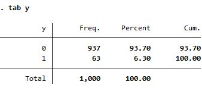

```r
firthlogit y x1 x2
#to create odds ratio with confidence intervals, use this code:
firthlogit y x1 x2, or
```

Here are the results from **firthlogit** with the large sample. It performs slightly better than regular **glm()** in recovering true parameters in the large sample.

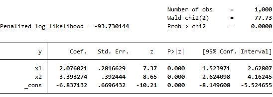

Now let’s examine **firthlogit** with the small sample and rare event. Here is a frequency table of the response variable:

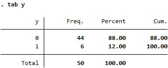

Here are the results from **firthlogit** with the small sample and rare events.

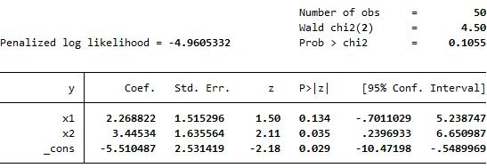

The **firthlogit** function did a good job here recovering the parameters, even with a small sample and rare events.